# Dokumentacja - język R

Dominik Krystkowiak Łukasz Śmierzchalski

24 11 2019

[figure not shown]

# Zdobywcy Oscara

Definicja nagród Oscara z Wikipedii:

> Nagroda Akademii Filmowej, znana też jako Oscar – nagroda przyznawana corocznie przez Amerykańską Akademię Sztuki i Wiedzy Filmowej w dziedzinie filmu.

Dane do analizy zostały pobrane ze strony https://people.sc.fsu.edu/~jburkardt/data/csv

## Wczytanie danych

Wczytanie danych odbywa się przy pomocy funkcji **read.table** z odpowiednimi parametrami:

- *file* - źródło danych
- *sep* - separator
- *header* - czy pierwszy wiersz ma być uznany za nagłówek

Funkcja **summary** pozwala na wypisanie podsumowania zawierającego wartość minimalną zbioru, 1 kwartyl, medianę, średnią, 3 kwartyl oraz wartość maksymalną.

Wczytanie danych dla aktorów oraz wyświetlenie podsumowania dla ich wieku w momencie zdobycia nagrody Oscara.

```r
actors_data <- read.table(file = "https://people.sc.fsu.edu/~jburkardt/data/csv/oscar_age_male.csv",
          sep=",", header=TRUE)

summary(actors_data["Age"])
```

```
##       Age
##  Min.   :29.00
##  1st Qu.:38.00
##  Median :42.00
##  Mean   :43.88
##  3rd Qu.:49.00
##  Max.   :76.00
```

```r
min_actors <- actors_data[which.min(actors_data$Age),]
max_actors <- actors_data[which.max(actors_data$Age),]
```

| Info | Rok uzyskania Oscara | Nazwisko | Film | Wiek |
| --- | --- | --- | --- | --- |
| Namłodsza | 2003 | Adrien Brody | The Pianist | 29 |
| Najstarsza | 1982 | Henry Fonda | On Golden Pond | 76 |

To samo zostało wykonane dla aktorek, które zdobyły Oscara.

```r
actress_data <- read.table(file = "https://people.sc.fsu.edu/~jburkardt/data/csv/oscar_age_female.csv",
          sep=",", header=TRUE)

summary(actress_data["Age"])
```

```
##       Age
##  Min.   :21.00
##  1st Qu.:28.00
##  Median :33.00
##  Mean   :36.12
##  3rd Qu.:41.00
##  Max.   :80.00
```

```r
min_actress <- actress_data[which.min(actress_data$Age),]
max_actress <- actress_data[which.max(actress_data$Age),]
```

| Info | Rok uzyskania Oscara | Nazwisko | Film | Wiek |
| --- | --- | --- | --- | --- |
| Namłodsza | 1987 | Marlee Matlin | Children of a Lesser God | 21 |
| Najstarsza | 1990 | Jessica Tandy | Driving Miss Daisy | 80 |

## Wykres liniowy

W celu sporządzenia wykresu liniowego połączono dane uzyskane w krokach poprzednich. Do tego wykorzystano funkcję **inner_join** (wewnętrzne złączenie) z pakietu **dplyr**. Funkcja przyjmuje dwie tabele, które chcemy złączyć oraz nazwę kolumny według której ma dojść do złączenia.

Do wyświetlenia wykresu użyto biblioteki **ggplot** przyjmująca zmienną z danymi oraz pozwaa na określenie co mają zawierać poszczególne osie. Funkcja **geom_line** umożliwia narysowanie poszczególnych linii na wykresie.

```r
merged_data <- dplyr::inner_join(actors_data, actress_data, by = "Year")

names(merged_data)[names(merged_data) == "Age.x"] <- "Age_actor"
names(merged_data)[names(merged_data) == "Age.y"] <- "Age_actress"

head(merged_data)
```

```
##   Index.x Year Age_actor            Name.x
## 1       1 1928        44     Emil Jannings
## 2       2 1929        41     Warner Baxter
## 3       3 1930        62     George Arliss
## 4       4 1931        53  Lionel Barrymore
## 5       5 1932        47     Wallace Beery
## 6       6 1933        35     Fredric March
##                                   Movie.x Index.y Age_actress
## 1  The Last Command, The Way of All Flesh       1          22
## 2                          In Old Arizona       2          37
## 3                                Disraeli       3          28
## 4                             A Free Soul       4          63
## 5                               The Champ       5          32
## 6                 Dr. Jekyll and Mr. Hyde       6          26
##               Name.y
## 1       Janet Gaynor
## 2      Mary Pickford
## 3      Norma Shearer
## 4     Marie Dressler
## 5        Helen Hayes
## 6  Katharine Hepburn
##                                                           Movie.y
## 1  Seventh Heaven, Street Angel and Sunrise: A Song of Two Humans
## 2                                                        Coquette
## 3                                                   The Divorcee\t
## 4                                                    Min and Bill
## 5                                     The Sin of Madelon Claudet\t
## 6                                                   Morning Glory
```

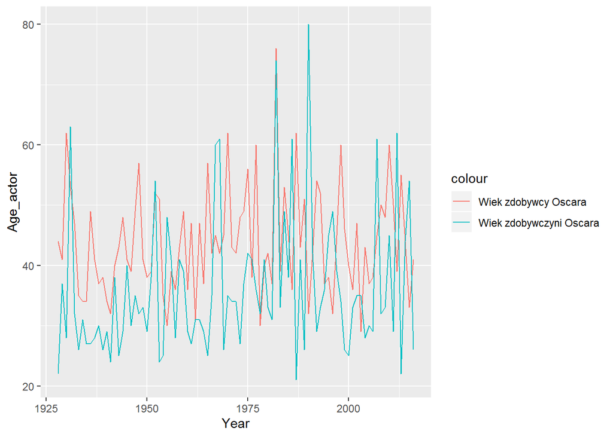

```r
ggplot(merged_data, aes(Year)) +
  geom_line(aes(y = Age_actor, colour = "Wiek zdobywcy Oscara")) +
  geom_line(aes(y = Age_actress, colour = "Wiek zdobywczyni Oscara"))
```

## Wykres pudełkowy

Poniżej zaprezentowano wykres pudełkowy dla wieku. Kółkiem oznaczone są wartości odstające.

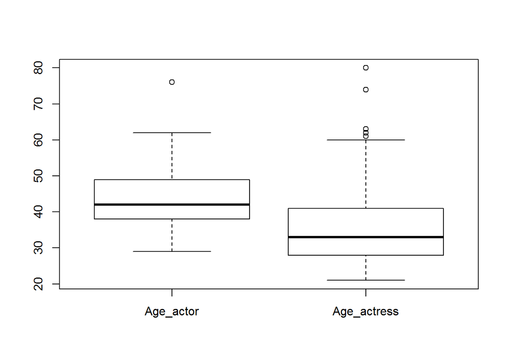

```r
boxplot(merged_data[, c("Age_actor", "Age_actress")])
```

## Histogram

```r
#http://www.sthda.com/english/wiki/ggplot2-histogram-plot-quick-start-guide-r-software-and-data-visualization
data_f <- data.frame(
  sex= "F",
  age=c(actress_data[,"Age"])
)
data_m <- data.frame(
  sex="M" ,
  age=c(actors_data[,"Age"])
)

merged_data_histogram = merge(data_f, data_m, all=TRUE)
head(merged_data_histogram)
```

```
##   sex age
## 1   F  21
## 2   F  22
## 3   F  22
## 4   F  24
## 5   F  24
## 6   F  25
```

```r
mu <- ddply(merged_data_histogram, "sex", summarise, grp.mean=mean(age))
print(mu)
```

```
##   sex grp.mean
## 1   F  36.1236
## 2   M  43.8764
```

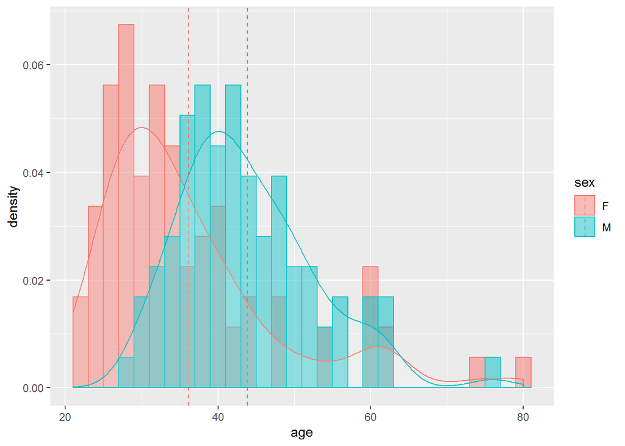

```r
ggplot(merged_data_histogram, aes(x=age, fill=sex, color=sex, y=..density..)) +
  geom_histogram( alpha=0.5, position="identity", binwidth=2)+
  geom_vline(data=mu, aes(xintercept=grp.mean, color=sex),
             linetype="dashed")+
  geom_density(alpha=.1, fill="#FFFFFF")
```

## Zeskrobywanie danych

```r
#https://www.freecodecamp.org/news/an-introduction-to-web-scraping-using-r-40284110c848/

url <- "https://www.amazon.in/OnePlus-Mirror-Black-64GB-Memory/dp/B0756Z43QS?tag=googinhydr18418-21&tag=googinkenshoo-21&ascsubtag=aee9a916-6acd-4409-92ca-3bdbeb549f80"

webpage <-  read_html(url)
print(webpage)
```

```
## {html_document}
## <html class="a-no-js" lang="en-us">
## [1] <head>\n<meta http-equiv="content-type" content="text/html; charset=UTF-8 ...
## [2] <body>\n\n<!--\n        To discuss automated access to Amazon data please ...
```

```r
title_html <- html_nodes(webpage, "#title")
title <- html_text(title_html)
print(gsub("[\r\n ]", "", title))
```

```
## character(0)
```